# Perceptron from Scratch

Kevin Patyk

1/22/2022

# Introduction

The perceptron algorithm is a supervised learning technique for binary classifiers in machine learning. A binary classifier is a function that can determine whether or not a vector of numbers representing an input belongs to a given class ($[0,1]$, $[yes, no]$, $[died, survived]$, etc.). It is a linear classifier, or a classification algorithm that uses a linear predictor function to combine a set of weights with a feature vector to create predictions for class assignment.

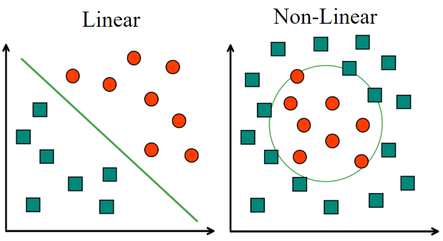

The perceptron consists of 4 parts:

- Input values or One input layer
- Weights and Bias
- Net sum
- Activation function

The activation function defines the output of a neuron/node given an input or set of inputs.

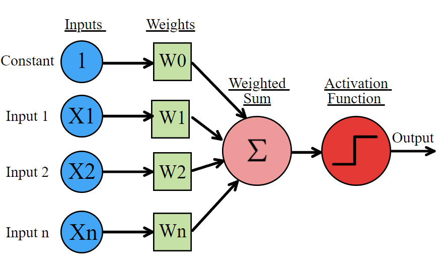

The perceptron works in these simples steps:

1. All the inputs $x$ are multiplied with their weights $w$.

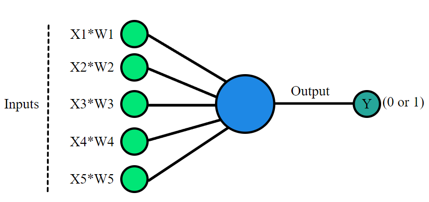

2. Add all the multiplied values and call them Weighted Sum.
3. Apply that weighted sum to the correct Activation Function.

**For example**: Unit Step Activation Function

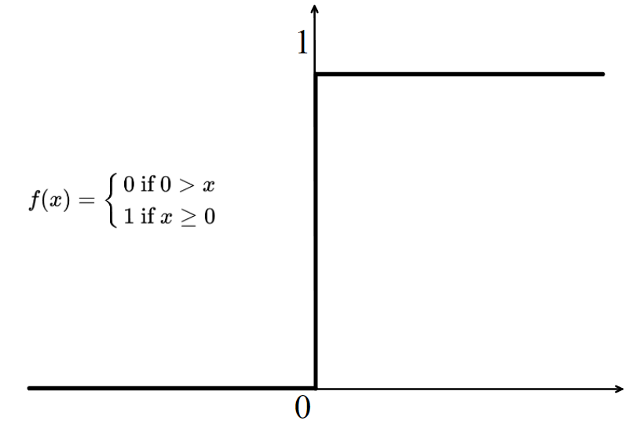

In perceptron, the weights ($w$) shows the strength of the particular node and the bias value ($b$) allows you to shift the activation function curve up or down. The activation function is used to map the input between the required values like $[0,1]$ or $[-1, 1]$.

So, essentially perceptron takes an input, aggregates it (weighted sum) and returns $1$ only if the aggregated sum is more than some threshold and returns $0$ otherwise.

# Perceptron calculations

Perceptron is a linear model with a linear function:

$$f(w,b) = w^Tx + b$$

After this linear model, we apply the activation function. In the simplest case, we apply the unit step activation function:

$$f(x)=\left\{\begin{array}{l}
0 \text { if } 0>x \\
1 \text { if } x \geq 0
\end{array}\right.$$

This is all we need to model the output. The entire output is first applying the linear function and then applying the activation function:

$$\hat{y} = g(f(w,b)) = g(w^Tx+b)$$

For this, we have to finds the weights $w$ and the bias $b$ using simple update rules.

The perceptron update rules are:

$$\text {For each training sample } x_i:$$

$$w = w+\Delta w$$
This is the new $w$ is equal to the old $w$ plus the delta weight $\Delta w$.

The delta weight $\Delta w$ is defined as:

$$\Delta w = \alpha \cdot (y_i-\hat{y}_i) \cdot x_i$$

The delta weight $\Delta w$ is equal to $\alpha$ multiplied by the (actual label minus the predicted label) times the training sample $x_i$.

Here $\alpha$ is the learning rate between $[0,1]$.

So what does this update rule mean? There are 4 possible outcomes in the case of binary classification.

1. The actual label ($y$) is $1$ and the predicted label ($\hat{y}$) is $1$. The difference ($y_i-\hat{y}_i$) is 0. This means the observation is correctly classified. In this situation, we have no change for the weights.
2. The actual label ($y$) is $0$ and the predicted label ($\hat{y}$) is $0$. The difference ($y_i-\hat{y}_i$) is 0. This means the observation is correctly classified. In this situation, we have no change for the weights.
3. The actual label ($y$) is $1$ and the predicted label ($\hat{y}$) is $0$. The difference ($y_i-\hat{y}_i$) is 1. This means the observation is misclassified. In this situation, our weights are too low and they should be increased.
4. The actual label ($y$) is $0$ and the predicted label ($\hat{y}$) is $1$. The difference ($y_i-\hat{y}_i$) is -1. This means the observation is misclassified. In this situation, our weights are too high and they should be decreased.

So, the weights $w$ are pushed towards the positive or negative class in the case of a misclassification.

We will perform this update rule for a set number of iterations or other stopping criterion is reached.

# Coding the algorithm

First we will load the libraries that we will use.

```r
library(tidyverse)
```

Then, let us make a linearly separable dataset that we can use the test the algorithm.

For this, we will be using the `iris` dataset, but removing one of the classes so only 2 remain. This dataset will also be provided in the `Data` folder. For the sake of simplicity, we will also only use 2 predictors, which are `Sepal.Length` and `Petal.Length`.

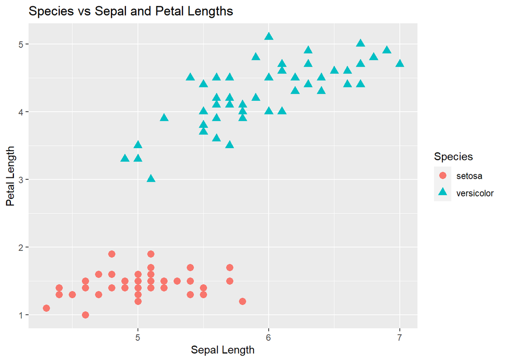

```r
#loading the iris data and making it binary
df <- iris[iris$Species != "virginica", ]
#selecting the x variables
x <- df[, c("Sepal.Length", "Petal.Length")]
#selecting the outcome variable
y <- as.character(df$Species)
#plotting
ggplot(df, aes(x = Sepal.Length, y = Petal.Length)) +
        geom_point(aes(colour = Species, shape = Species), size = 3) +
        xlab("Sepal Length") +
        ylab("Petal Length") +
        ggtitle("Species vs Sepal and Petal Lengths")
```

As we can see, the two classes are linearly separable.

```r
#converting the labels to 0 and 1
y <- ifelse(y == "setosa", 0, 1)
#inspecting the predictors
head(x)
```

```
##   Sepal.Length Petal.Length
## 1          5.1          1.4
## 2          4.9          1.4
## 3          4.7          1.3
## 4          4.6          1.5
## 5          5.0          1.4
## 6          5.4          1.7
```

```r
#inspecting the outcome
table(y)
```

```
## y
##  0  1
## 50 50
```

Now it is time to code the function.

```r
perceptron <- function(X, y, alpha, n_iter){

  #defining the learning rate
  alpha <- alpha
  #defining the number of iterations
  n_iter <- n_iter

  #initializing the weights
  w <- rep(0, ncol(x) + 1)
  #converting x to a matrix
  X <- as.matrix(X)

  #loop over the number of iterations
  for(i in 1:n_iter){

    #loop through the training data
    for(j in 1:length(y)){

      #predicting the binary label according to the Heaviside (unit step) activation function
      z <- sum(w[2:length(w)] * X[j, ]) + w[1]
      if(z >= 0){
        y_pred <- 1
      } else{
        y_pred <- 0
      }

      #now updating the weights; the formula doesn't do anything if the predicted value is correct
      dw <- alpha * (y[j] - y_pred) * c(1, X[j, ])
      w <- w + dw

    }
  }

  #returning the weights
  return(w)
}
```

Let us now see if the function works as intended and make predictions.

```r
#running our algorithm
weights <- perceptron(X = x, y = y, alpha = 0.01, n_iter = 5000)

#defining the prediction function
pred <- function(X, w){
  #adding an intercept to
  X$Intercept <- 1
  #rearranging so intercept comes first and making into a matrix
  X <- as.matrix(X[, c(ncol(X), 1:(ncol(X)-1))])
  #making predictions
  pred <- X %*% w
  #changing the labels
  pred_label <- ifelse(pred >= 0, 1, 0)

  #returning the predicted values
  return(pred_label)
}
```

Now lets make predictions and double check if the algorithm gives the correct labels.

```r
#making predictions
pred_perc <- pred(X = x, w = weights)
#making a table of our predictions using the algorithm
table(pred_perc)
```

```
## pred_perc
##  0  1
## 50 50
```

```r
#making a table of our actual y
table(y)
```

```
## y
##  0  1
## 50 50
```

As we can see, they are exactly the same. Thus, our perceptron algorithm from scratch has successfully classified the data with 100% accuracy.

Now let’s plot the predicted classes, the same as we did before using `ggplot` with the actual classes.

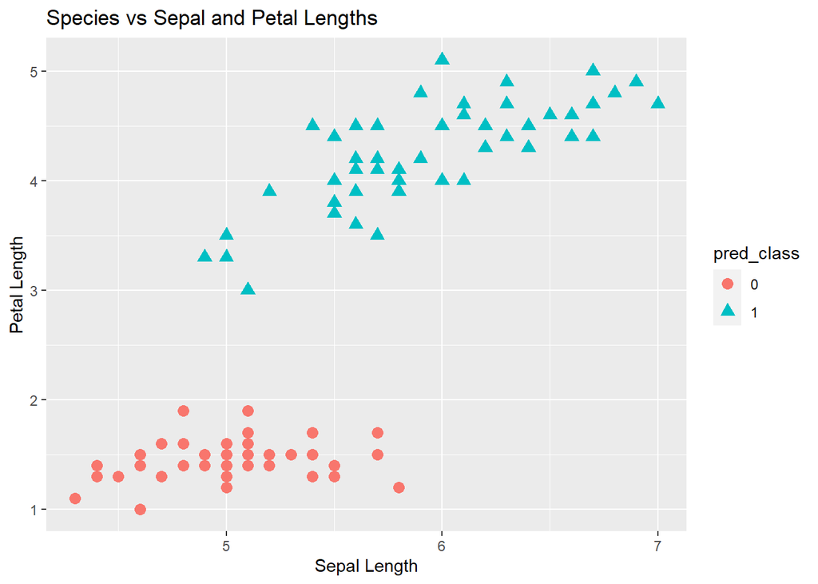

```r
x %>%
  mutate(pred_class = as.factor(pred_perc)) %>%
  ggplot(aes(x = Sepal.Length, y = Petal.Length)) +
        geom_point(aes(colour = pred_class, shape = pred_class), size = 3) +
        xlab("Sepal Length") +
        ylab("Petal Length") +
        ggtitle("Species vs Sepal and Petal Lengths")
```

We have successfully coded perceptron from scratch.